# GeolocationSheafEx_OF

Olivia Freides

5/23/2022

# Modeling the Geolocation Sheaf:

For specifics and citations, reference https://arxiv.org/abs/1912.05487

@misc{https://doi.org/10.48550/arxiv.1912.05487, doi = {10.48550/ARXIV.1912.05487},

url = {https://arxiv.org/abs/1912.05487},

author = {Joslyn, Cliff and Charles, Lauren and DePerno, Chris and Gould, Nicholas and Nowak, Kathleen and Praggastis, Brenda and Purvine, Emilie and Robinson, Michael and Strules, Jennifer and Whitney, Paul},

keywords = {Data Analysis, Statistics and Probability (physics.data-an), FOS: Physical sciences, FOS: Physical sciences},

title = {A Sheaf Theoretical Approach to Uncertainty Quantification of Heterogeneous Geolocation Information},

publisher = {arXiv},

year = {2019},

copyright = {arXiv.org perpetual, non-exclusive license} }

```r
library(tidyverse)
library(sp)
library(sf)
library(rgdal)
library(osmdata)
```

Sensors:

- The GPS reading on the Bear Collar, denoted $\textbf{G};$
- The Radio VHF Device receiver, denoted $\textbf{R};$
- The Text report, denoted $\textbf{T};$ and
- The Vehicle GPS, denoted $\textbf{V}.$

Where $\textbf{G}$ and $\textbf{R}$ trace location of the bear, and $\textbf{R}$, $\textbf{T}$, and $\textbf{V}$ trace the location of the researcher.

$\textbf{U = \{V, R, T, G\}}$ base sensor set ASC $\Delta$, representing the tracking sensor network, contains the face denoted $H = \{V, R, T \}$ and all nine faces are  
$\Delta$ = { {V, R, T},  
{V, T}, {R, T}, {V, R},  
{R, G}, {V}, {R}, {T}, {G} }

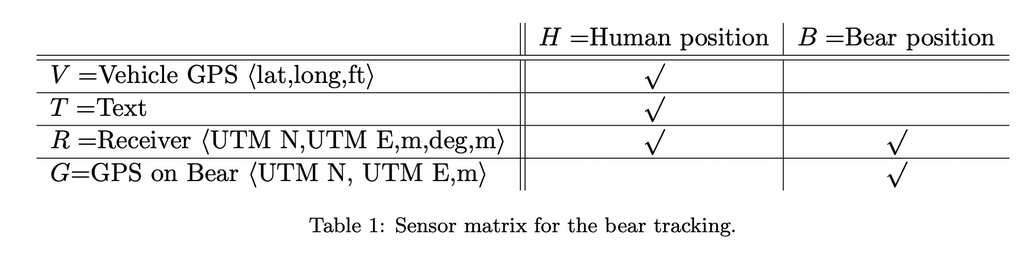

Table 1

With Pairwise interactions X, Y, and Z = {V, T,}, {V, R}, and {R, T} respectively.

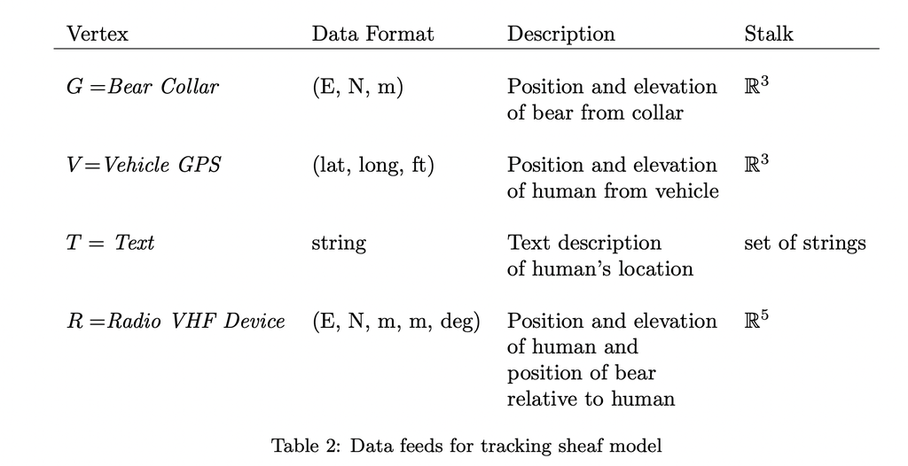

Table 2

To convert the text descriptions we use Google Maps API [63] and to convert the (lat, long, ft) readings, coming from the vehicle, we use the Python open source package utm 0.4.1 [64].

$$\phi: \mathbb{R}^5 \to \mathbb{R}^5, \phi((x, y, z, r, \theta)^T) = (x, y, z, r cos(\theta), rsin(\theta))^T$$

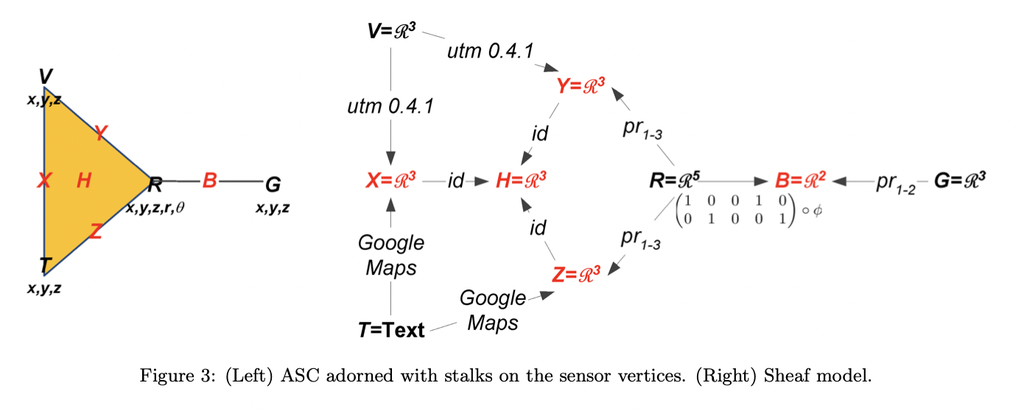

Figure 3

# UPDATE MODEL:

X, Z, H -> R2. Z coord not available from openstreet text. Now X, Z, H = (x, y).

## Restriction Functions:

IDs

Since the pairwise relations all share UTM coordinates, only ID mappings are needed among them – up to the three-way H face.

In total there are 12 ID functions.

```r
ID_V <- function(stalk){
  stalk %>%
    select(c(x, y, z))
}
```

```r
ID_T <- function(stalk){
  stalk %>%
    select(c(Text))
}
```

```r
ID_R <- function(stalk){
  stalk %>%
    select(c(x, y, z, r, theta))
}
```

```r
ID_G <- function(stalk){
  stalk %>%
    select(c(x, y, z))
}
```

```r
ID_X <- function(stalk){
  stalk %>%
    select(c(x, y))
}
```

```r
ID_Y <- function(stalk){
  stalk %>%
    select(c(x, y, z))
}
```

```r
ID_Z <- function(stalk){
  stalk %>%
    select(c(x, y))
}
```

```r
ID_B <- function(stalk){
  stalk %>%
    select(c(x, y))
}
```

```r
ID_H <- function(stalk){
  stalk %>%
    select(c(x, y))
}
```

```r
ID_YH <- function(stalk){
  stalk %>%
    select(c(x, y))
}
```

```r
ID_ZH <- function(stalk){
  stalk %>%
    select(c(x, y))
}
```

```r
ID_XH <- function(stalk){
  stalk %>%
    select(c(x, y))
}
```

UTM 0.4.1 functions

For reference on the string specification being out of date: https://inbo.github.io/tutorials/tutorials/spatial_crs_coding/

```r
UTM_VX <- function(stalk){
  coordsNA <- c() # init matrix
  coordsNA$x <- as.numeric(stalk$long) #base r matrix gets info from order inputted not names
  coordsNA$y <- as.numeric(stalk$lat)
  SpatialPoints(coordsNA, proj4string = CRS("+proj=longlat +datum=WGS84")) -> llcoords # makes s4
  spTransform(llcoords, CRS("+proj=utm +zone=17 +datum=WGS84 +units=m")) -> tcoords
  tibble(x = tcoords$x, y = tcoords$y, z = stalk$z*0.3048)
}
```

```r
UTM_VY <- function(stalk){
  coordsNA <- c() # init matrix
  coordsNA$x <- as.numeric(stalk$long) #base r matrix gets info from order inputted not names
  coordsNA$y <- as.numeric(stalk$lat)
  SpatialPoints(coordsNA, proj4string = CRS("+proj=longlat +datum=WGS84")) -> llcoords # makes s4
  spTransform(llcoords, CRS("+proj=utm +zone=17 +datum=WGS84 +units=m")) -> tcoords
  tibble(x = tcoords$x, y = tcoords$y, z = stalk$z*0.3048)
}
```

Google Maps -> OpenStreetMap Data. For a cost free solution, I used OpenStreetMap data instead of Google Maps API.

Feed OpenStreetMap a text, get lat long, turn to UTM:

```r
textcoords <- function(stalk, inputcity){ # take in the stalk + the input city in quotes

  stalk %>%
    select(Text) -> string

# Need to get names of the roads only. First select the street name.
# For example, Woodly Road. Second, select only the name, Woodly.

  string %>%
    str_extract_all('([\\w]*?\\S+).(Rd|Road|St|Hwy|Highway|Dr|Ln|Lane|Ct|Court|Ave|Pl)') %>%
    unlist()%>%
    str_extract_all('\\b(?!(Rd|Road|St|Hwy|Highway|Dr|Ln|Lane|Ct|Court|Ave|Pl)\\b)\\w+') -> names

  #readline(prompt = "Enter City in Quotes: ") -> inputcity
  print(inputcity) # checkpt
  city <- getbb(inputcity) # get bounding box for city.
  #head(city) #checkpt

# Check database for the road. get sf object.
  citystreets <- city %>%
    opq() %>%
    add_osm_feature("highway", c("motorway", "primary", "secondary", "tertiary", "residential","living_street","unclassified", "service", "footway")) %>%
    osmdata_sf()

  print(citystreets) #checkpt, non-zero?

  #find coordinates of the first road
  tibble(name = citystreets$osm_lines$name, geometry = citystreets$osm_lines$geometry) %>% # geometries are linestring objects
    filter(grepl(names[[1]], name)) %>%
    mutate(points = map(geometry, ~st_coordinates(.) %>% as.data.frame())) %>% # retrieve coordinates in matrix form
    unnest(points)-> geompoints_rd1 # coords to match
  print(geompoints_rd1)

  # find coordinates of the second road
  tibble(name = citystreets$osm_lines$name, geometry = citystreets$osm_lines$geometry) %>%
    filter(grepl(names[[2]], name)) %>%
    mutate(points = map(geometry, ~st_coordinates(.) %>% as.data.frame())) %>%
    unnest(points)-> geompoints_rd2 # coords to match
  print(geompoints_rd2)

  # Hope that they intersect! Inner join on the intersection, which gives lat and long of street intersection.
  inner_join(geompoints_rd1, geompoints_rd2, by = c(X = "X", Y = "Y"))%>%
    select(X, Y) %>% head(1) %>%
    transmute(lat= Y, long = X)
}

# base test:
stalk <- data.frame(Text = c("Intersection at Victoria Rd and Meadow Rd"))
stalk2 <- data.frame(Text = c("Intersection of Wood Ave and Parker Road"))
# Further testing should be done with numbered streets

textcoords(stalk, "Asheville")
```

```
## [1] "Asheville"
```

[output not shown]

[output not shown]

```
## Object of class 'osmdata' with:
##                  $bbox : 35.4164642,-82.6703643,35.6560763,-82.4604691
##         $overpass_call : The call submitted to the overpass API
##                  $meta : metadata including timestamp and version numbers
##            $osm_points : 'sf' Simple Features Collection with 207213 points
##             $osm_lines : 'sf' Simple Features Collection with 22159 linestrings
##          $osm_polygons : 'sf' Simple Features Collection with 240 polygons
##        $osm_multilines : NULL
##     $osm_multipolygons : NULL
```

```
## # A tibble: 132 × 5
##    name                                               geometry     X     Y    L1
##    <chr>                                      <LINESTRING [°]> <dbl> <dbl> <dbl>
##  1 Victoria Road (-82.55106 35.57784, -82.5512 35.57773, -82.… -82.6  35.6     1
##  2 Victoria Road (-82.55106 35.57784, -82.5512 35.57773, -82.… -82.6  35.6     1
##  3 Victoria Road (-82.55106 35.57784, -82.5512 35.57773, -82.… -82.6  35.6     1
##  4 Victoria Road (-82.55106 35.57784, -82.5512 35.57773, -82.… -82.6  35.6     1
##  5 Victoria Road (-82.55106 35.57784, -82.5512 35.57773, -82.… -82.6  35.6     1
##  6 Victoria Road (-82.55106 35.57784, -82.5512 35.57773, -82.… -82.6  35.6     1
##  7 Victoria Road (-82.55106 35.57784, -82.55097 35.57808, -82… -82.6  35.6     1
##  8 Victoria Road (-82.55106 35.57784, -82.55097 35.57808, -82… -82.6  35.6     1
##  9 Victoria Road (-82.55106 35.57784, -82.55097 35.57808, -82… -82.6  35.6     1
## 10 Victoria Road (-82.55106 35.57784, -82.55097 35.57808, -82… -82.6  35.6     1
## # … with 122 more rows
## # A tibble: 713 × 5
##    name                                               geometry     X     Y    L1
##    <chr>                                      <LINESTRING [°]> <dbl> <dbl> <dbl>
##  1 Brook Meadow Lane     (-82.48762 35.47852, -82.48731 35.47… -82.5  35.5     1
##  2 Brook Meadow Lane     (-82.48762 35.47852, -82.48731 35.47… -82.5  35.5     1
##  3 Brook Meadow Lane     (-82.48762 35.47852, -82.48731 35.47… -82.5  35.5     1
##  4 Brook Meadow Lane     (-82.48762 35.47852, -82.48731 35.47… -82.5  35.5     1
##  5 Mallory Meadows Court (-82.49185 35.45209, -82.49186 35.45… -82.5  35.5     1
##  6 Mallory Meadows Court (-82.49185 35.45209, -82.49186 35.45… -82.5  35.5     1
##  7 Mallory Meadows Court (-82.49185 35.45209, -82.49186 35.45… -82.5  35.5     1
##  8 Mallory Meadows Court (-82.49185 35.45209, -82.49186 35.45… -82.5  35.5     1
##  9 Mallory Meadows Court (-82.49185 35.45209, -82.49186 35.45… -82.5  35.5     1
## 10 Mallory Meadows Court (-82.49185 35.45209, -82.49186 35.45… -82.5  35.5     1
## # … with 703 more rows
```

| lat | long |
| --- | --- |
| 35.5654 | -82.5566 |

```r
OSM_TX <- function(stalk){
  stalk %>%
    textcoords("Asheville") %>% # pipe in stalk, then add input city, here from the paper we are in Asheville.
    UTM_VX()
}
```

```r
OSM_TZ <- function(stalk){
    stalk %>%
    textcoords("Asheville") %>%
    UTM_VX()
}
```

$pr_{x-y}$: Labels of the form prx-y are projections of the corresponding coordinates (also presentable as binary matrices of the appropriate form).

$pr_{1-2}$

```r
PRgb_1_2 <- function(stalk){
  stalk %>%
    select(c(x, y))
}
```

$pr_{1-3}$

```r
PRry_1_3 <- function(stalk){
  stalk %>%
    select(c(x, y, z))
}
```

```r
PRrz_1_3 <- function(stalk){
  stalk %>%
    select(c(x, y))
}
```

“Finally, the restriction from R up to B is the composition of the polar conversion of the final two components with the projection on the first two to predict the bear position from the radiocollar GPS, bearing, and range.”

$$\begin{pmatrix}
1 & 0 & 0 & 1 & 0\\
0 & 1 & 0 & 0 & 1
\end{pmatrix} \circ
\phi:(x, y, z, r cos(\theta), rsin(\theta))^T$$

```r
phi_RB <- function(stalk){
  stalk %>%
    mutate(x = x+r*sin(theta*pi/180), y = y+r*cos(theta*pi/180)) %>%
    select(c(x, y))
}
```

## Assignment Table:

Global section inputs for case 1:

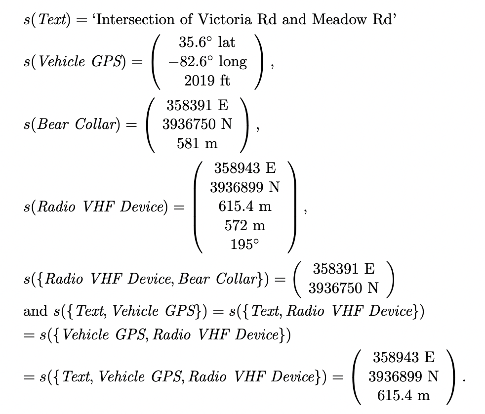

```r
Table <- read.csv("GeoAssignmentTable.csv")
Table
```

| sensor | key | entity | case1 | case2 | units |
| --- | --- | --- | --- | --- | --- |
| Bear Collar | G | x | 358391 | 362888 | E |
| Bear Collar | G | y | 3936750 | 3938373 | N |
| Bear Collar | G | z | 581 | 577 | m |
| Vehicle GPS | V | lat | 35.56574 | 35.571411 | lat |
| Vehicle GPS | V | long | -82.556529 | -82.515491 | long |
| Vehicle GPS | V | z | 2019 | 2174 | ft |
| Text | T | Text | "Intersection of Victoria Rd and Meadow Rd" | "Wood Ave. at Parker Rd" | Text |
| Radio VHF Device | R | x | 358943 | 362666 | E |
| Radio VHF Device | R | y | 3936899 | 3937469 | N |
| Radio VHF Device | R | z | 615.4 | 643 | m |

[output cut: 16 more lines]

## MODEL:

```r
model <- tibble(map = c(ID_V, ID_T, ID_R, ID_G, ID_X, ID_Y, ID_Z, ID_B, ID_H, UTM_VX, UTM_VY,phi_RB,PRgb_1_2, PRry_1_3, PRrz_1_3, ID_YH, ID_ZH, ID_XH, OSM_TZ, OSM_TX),
                    source = c("V", "T", "R", "G", "X", "Y", "Z", "B", "H", "V", "V", "R", "G", "R", "R", "Y", "Z", "X", "T", "T"), #key == source
                    dest =   c("V", "T", "R", "G", "X", "Y", "Z", "B", "H", "X", "Y", "B", "B", "Y", "Z", "H", "H", "H", "Z", "X"))

as.data.frame(model) -> model #20x11
# Checked all sources and dests match functions √
```

Attach model to table, and execute functions to make full sheaf model with outputs:

```r
Table %>%
  select(entity, case1, key)%>%
  pivot_wider(names_from = entity, values_from = case1)%>%
  mutate(across(c(x, y, z, lat, long, theta, r), as.numeric))%>% # needed to transform from chr to dbl.
  right_join(model, by = c(key = "source")) %>%
  nest(stalkinput = 2:9) %>%
  mutate(stalkoutput = map2(.x= map, .y = stalkinput, .f = exec)) -> sheaf # These were all global sections, should have cons.rad of 0
```

```
## [1] "Asheville"
```

[output not shown]

```
## Object of class 'osmdata' with:
##                  $bbox : 35.4164642,-82.6703643,35.6560763,-82.4604691
##         $overpass_call : The call submitted to the overpass API
##                  $meta : metadata including timestamp and version numbers
##            $osm_points : 'sf' Simple Features Collection with 207213 points
##             $osm_lines : 'sf' Simple Features Collection with 22159 linestrings
##          $osm_polygons : 'sf' Simple Features Collection with 240 polygons
##        $osm_multilines : NULL
##     $osm_multipolygons : NULL
```

```
## # A tibble: 132 × 5
##    name                                               geometry     X     Y    L1
##    <chr>                                      <LINESTRING [°]> <dbl> <dbl> <dbl>
##  1 Victoria Road (-82.55106 35.57784, -82.5512 35.57773, -82.… -82.6  35.6     1
##  2 Victoria Road (-82.55106 35.57784, -82.5512 35.57773, -82.… -82.6  35.6     1
##  3 Victoria Road (-82.55106 35.57784, -82.5512 35.57773, -82.… -82.6  35.6     1
##  4 Victoria Road (-82.55106 35.57784, -82.5512 35.57773, -82.… -82.6  35.6     1
##  5 Victoria Road (-82.55106 35.57784, -82.5512 35.57773, -82.… -82.6  35.6     1
##  6 Victoria Road (-82.55106 35.57784, -82.5512 35.57773, -82.… -82.6  35.6     1
##  7 Victoria Road (-82.55106 35.57784, -82.55097 35.57808, -82… -82.6  35.6     1
##  8 Victoria Road (-82.55106 35.57784, -82.55097 35.57808, -82… -82.6  35.6     1
##  9 Victoria Road (-82.55106 35.57784, -82.55097 35.57808, -82… -82.6  35.6     1
## 10 Victoria Road (-82.55106 35.57784, -82.55097 35.57808, -82… -82.6  35.6     1
## # … with 122 more rows
## # A tibble: 713 × 5
##    name                                               geometry     X     Y    L1
##    <chr>                                      <LINESTRING [°]> <dbl> <dbl> <dbl>
##  1 Brook Meadow Lane     (-82.48762 35.47852, -82.48731 35.47… -82.5  35.5     1
##  2 Brook Meadow Lane     (-82.48762 35.47852, -82.48731 35.47… -82.5  35.5     1
##  3 Brook Meadow Lane     (-82.48762 35.47852, -82.48731 35.47… -82.5  35.5     1
##  4 Brook Meadow Lane     (-82.48762 35.47852, -82.48731 35.47… -82.5  35.5     1
##  5 Mallory Meadows Court (-82.49185 35.45209, -82.49186 35.45… -82.5  35.5     1
##  6 Mallory Meadows Court (-82.49185 35.45209, -82.49186 35.45… -82.5  35.5     1
##  7 Mallory Meadows Court (-82.49185 35.45209, -82.49186 35.45… -82.5  35.5     1
##  8 Mallory Meadows Court (-82.49185 35.45209, -82.49186 35.45… -82.5  35.5     1
##  9 Mallory Meadows Court (-82.49185 35.45209, -82.49186 35.45… -82.5  35.5     1
## 10 Mallory Meadows Court (-82.49185 35.45209, -82.49186 35.45… -82.5  35.5     1
## # … with 703 more rows
```

```
## [1] "Asheville"
```

```
## Object of class 'osmdata' with:
##                  $bbox : 35.4164642,-82.6703643,35.6560763,-82.4604691
##         $overpass_call : The call submitted to the overpass API
##                  $meta : metadata including timestamp and version numbers
##            $osm_points : 'sf' Simple Features Collection with 207213 points
##             $osm_lines : 'sf' Simple Features Collection with 22159 linestrings
##          $osm_polygons : 'sf' Simple Features Collection with 240 polygons
##        $osm_multilines : NULL
##     $osm_multipolygons : NULL
```

```
## # A tibble: 132 × 5
##    name                                               geometry     X     Y    L1
##    <chr>                                      <LINESTRING [°]> <dbl> <dbl> <dbl>
##  1 Victoria Road (-82.55106 35.57784, -82.5512 35.57773, -82.… -82.6  35.6     1
##  2 Victoria Road (-82.55106 35.57784, -82.5512 35.57773, -82.… -82.6  35.6     1
##  3 Victoria Road (-82.55106 35.57784, -82.5512 35.57773, -82.… -82.6  35.6     1
##  4 Victoria Road (-82.55106 35.57784, -82.5512 35.57773, -82.… -82.6  35.6     1
##  5 Victoria Road (-82.55106 35.57784, -82.5512 35.57773, -82.… -82.6  35.6     1
##  6 Victoria Road (-82.55106 35.57784, -82.5512 35.57773, -82.… -82.6  35.6     1
##  7 Victoria Road (-82.55106 35.57784, -82.55097 35.57808, -82… -82.6  35.6     1
##  8 Victoria Road (-82.55106 35.57784, -82.55097 35.57808, -82… -82.6  35.6     1
##  9 Victoria Road (-82.55106 35.57784, -82.55097 35.57808, -82… -82.6  35.6     1
## 10 Victoria Road (-82.55106 35.57784, -82.55097 35.57808, -82… -82.6  35.6     1
## # … with 122 more rows
## # A tibble: 713 × 5
##    name                                               geometry     X     Y    L1
##    <chr>                                      <LINESTRING [°]> <dbl> <dbl> <dbl>
##  1 Brook Meadow Lane     (-82.48762 35.47852, -82.48731 35.47… -82.5  35.5     1
##  2 Brook Meadow Lane     (-82.48762 35.47852, -82.48731 35.47… -82.5  35.5     1
##  3 Brook Meadow Lane     (-82.48762 35.47852, -82.48731 35.47… -82.5  35.5     1
##  4 Brook Meadow Lane     (-82.48762 35.47852, -82.48731 35.47… -82.5  35.5     1
##  5 Mallory Meadows Court (-82.49185 35.45209, -82.49186 35.45… -82.5  35.5     1
##  6 Mallory Meadows Court (-82.49185 35.45209, -82.49186 35.45… -82.5  35.5     1
##  7 Mallory Meadows Court (-82.49185 35.45209, -82.49186 35.45… -82.5  35.5     1
##  8 Mallory Meadows Court (-82.49185 35.45209, -82.49186 35.45… -82.5  35.5     1
##  9 Mallory Meadows Court (-82.49185 35.45209, -82.49186 35.45… -82.5  35.5     1
## 10 Mallory Meadows Court (-82.49185 35.45209, -82.49186 35.45… -82.5  35.5     1
## # … with 703 more rows
```

```r
Table %>%
  select(entity, case2, key)%>%
  pivot_wider(names_from = entity, values_from = case2)%>%
  mutate(across(c(x, y, z, lat, long, theta, r), as.numeric))%>% # needed to transform from chr to dbl.
  right_join(model, by = c(key = "source")) %>%
  nest(stalkinput = 2:9) %>%
  mutate(stalkoutput = map2(.x= map, .y = stalkinput, .f = exec)) -> sheaf2
```

```
## [1] "Asheville"
```

```
## Error in curl::curl_fetch_memory(url, handle = handle): HTTP/2 stream 0 was not closed cleanly: PROTOCOL_ERROR (err 1)
## Request failed [ERROR]. Retrying in 1.6 seconds...
## Object of class 'osmdata' with:
##                  $bbox : 35.4164642,-82.6703643,35.6560763,-82.4604691
##         $overpass_call : The call submitted to the overpass API
##                  $meta : metadata including timestamp and version numbers
##            $osm_points : 'sf' Simple Features Collection with 207213 points
##             $osm_lines : 'sf' Simple Features Collection with 22159 linestrings
##          $osm_polygons : 'sf' Simple Features Collection with 240 polygons
##        $osm_multilines : NULL
##     $osm_multipolygons : NULL
```

```
## # A tibble: 1,238 × 5
##    name                                               geometry     X     Y    L1
##    <chr>                                      <LINESTRING [°]> <dbl> <dbl> <dbl>
##  1 The Woods Town Homes (-82.55838 35.61296, -82.55839 35.612… -82.6  35.6     1
##  2 The Woods Town Homes (-82.55838 35.61296, -82.55839 35.612… -82.6  35.6     1
##  3 The Woods Town Homes (-82.55838 35.61296, -82.55839 35.612… -82.6  35.6     1
##  4 The Woods Town Homes (-82.55838 35.61296, -82.55839 35.612… -82.6  35.6     1
##  5 The Woods Town Homes (-82.55838 35.61296, -82.55839 35.612… -82.6  35.6     1
##  6 South Wood Alley     (-82.51563 35.56994, -82.51564 35.570… -82.5  35.6     1
##  7 South Wood Alley     (-82.51563 35.56994, -82.51564 35.570… -82.5  35.6     1
##  8 South Wood Alley     (-82.51563 35.56994, -82.51564 35.570… -82.5  35.6     1
##  9 South Wood Alley     (-82.51563 35.56994, -82.51564 35.570… -82.5  35.6     1
## 10 South Wood Alley     (-82.51563 35.56994, -82.51564 35.570… -82.5  35.6     1
## # … with 1,228 more rows
## # A tibble: 55 × 5
##    name                                               geometry     X     Y    L1
##    <chr>                                      <LINESTRING [°]> <dbl> <dbl> <dbl>
##  1 Parker Road (-82.47209 35.63155, -82.47215 35.63166, -82.4… -82.5  35.6     1
##  2 Parker Road (-82.47209 35.63155, -82.47215 35.63166, -82.4… -82.5  35.6     1
##  3 Parker Road (-82.47209 35.63155, -82.47215 35.63166, -82.4… -82.5  35.6     1
##  4 Parker Road (-82.47209 35.63155, -82.47215 35.63166, -82.4… -82.5  35.6     1
##  5 Parker Road (-82.47209 35.63155, -82.47215 35.63166, -82.4… -82.5  35.6     1
##  6 Parker Road (-82.47209 35.63155, -82.47215 35.63166, -82.4… -82.5  35.6     1
##  7 Parker Road (-82.47209 35.63155, -82.47215 35.63166, -82.4… -82.5  35.6     1
##  8 Parker Road (-82.47209 35.63155, -82.47215 35.63166, -82.4… -82.5  35.6     1
##  9 Parker Road (-82.47209 35.63155, -82.47215 35.63166, -82.4… -82.5  35.6     1
## 10 Parker Road (-82.47209 35.63155, -82.47215 35.63166, -82.4… -82.5  35.6     1
## # … with 45 more rows
```

```
## [1] "Asheville"
```

[output not shown]

[output not shown]

[output not shown]

[output not shown]

```
## Object of class 'osmdata' with:
##                  $bbox : 35.4164642,-82.6703643,35.6560763,-82.4604691
##         $overpass_call : The call submitted to the overpass API
##                  $meta : metadata including timestamp and version numbers
##            $osm_points : 'sf' Simple Features Collection with 207213 points
##             $osm_lines : 'sf' Simple Features Collection with 22159 linestrings
##          $osm_polygons : 'sf' Simple Features Collection with 240 polygons
##        $osm_multilines : NULL
##     $osm_multipolygons : NULL
```

```
## # A tibble: 1,238 × 5
##    name                                               geometry     X     Y    L1
##    <chr>                                      <LINESTRING [°]> <dbl> <dbl> <dbl>
##  1 The Woods Town Homes (-82.55838 35.61296, -82.55839 35.612… -82.6  35.6     1
##  2 The Woods Town Homes (-82.55838 35.61296, -82.55839 35.612… -82.6  35.6     1
##  3 The Woods Town Homes (-82.55838 35.61296, -82.55839 35.612… -82.6  35.6     1
##  4 The Woods Town Homes (-82.55838 35.61296, -82.55839 35.612… -82.6  35.6     1
##  5 The Woods Town Homes (-82.55838 35.61296, -82.55839 35.612… -82.6  35.6     1
##  6 South Wood Alley     (-82.51563 35.56994, -82.51564 35.570… -82.5  35.6     1
##  7 South Wood Alley     (-82.51563 35.56994, -82.51564 35.570… -82.5  35.6     1
##  8 South Wood Alley     (-82.51563 35.56994, -82.51564 35.570… -82.5  35.6     1
##  9 South Wood Alley     (-82.51563 35.56994, -82.51564 35.570… -82.5  35.6     1
## 10 South Wood Alley     (-82.51563 35.56994, -82.51564 35.570… -82.5  35.6     1
## # … with 1,228 more rows
## # A tibble: 55 × 5
##    name                                               geometry     X     Y    L1
##    <chr>                                      <LINESTRING [°]> <dbl> <dbl> <dbl>
##  1 Parker Road (-82.47209 35.63155, -82.47215 35.63166, -82.4… -82.5  35.6     1
##  2 Parker Road (-82.47209 35.63155, -82.47215 35.63166, -82.4… -82.5  35.6     1
##  3 Parker Road (-82.47209 35.63155, -82.47215 35.63166, -82.4… -82.5  35.6     1
##  4 Parker Road (-82.47209 35.63155, -82.47215 35.63166, -82.4… -82.5  35.6     1
##  5 Parker Road (-82.47209 35.63155, -82.47215 35.63166, -82.4… -82.5  35.6     1
##  6 Parker Road (-82.47209 35.63155, -82.47215 35.63166, -82.4… -82.5  35.6     1
##  7 Parker Road (-82.47209 35.63155, -82.47215 35.63166, -82.4… -82.5  35.6     1
##  8 Parker Road (-82.47209 35.63155, -82.47215 35.63166, -82.4… -82.5  35.6     1
##  9 Parker Road (-82.47209 35.63155, -82.47215 35.63166, -82.4… -82.5  35.6     1
## 10 Parker Road (-82.47209 35.63155, -82.47215 35.63166, -82.4… -82.5  35.6     1
## # … with 45 more rows
```

```r
# This one should not have cons.rad of 0

#Both cases work! Problem lies in connection for osmdata sometimes it doesnt run... not my problem.
```

# Global Sections

Definition 3:

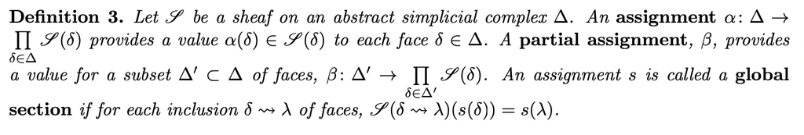

Definition 3

***** PLEASE NOTE THAT I CANNOT FIGURE OUT DATA FOR TABLE FOR EXAMPLE 5.2…, IF ITS THERE PLS HELP. *******

# Consistency Radius:

******* BELOW ARE NOTES FROM SHEAFCANON, REDO FOR GEO *******

$$d_U(x,y) = \sqrt{\sum_{i \in columns} \frac{A_i}{ncol} | x_i - y_i| ^2}$$
A is the unit conversion.

We converted everything to radians.

Unit Conversions

```r
# variables: x, y, z, lat, long, theta, text, r
UnitScale <- tibble(variable = c("x", "y", "z", "lat", "long", "theta", "Text", "r"),
                    #scale = c(1, 1, 1, 1, 1, 1, 1, 1))
                    #           long, lat, ft, lat, long, deg, text,meters
                      scale = c(1, 1, 1/0.3048, 1, 1, pi/180, 1, 1)) # Scaling units
# UTM IS IN METESR, SO DONT CHANGE THOSE LAT LONGS....

SensorScale <- sheaf %>% count(dest) # Scaling Sensors, by n?
```

```r
#Consistency Variance
sheaf %>%
  group_by(dest) %>%
  unnest(stalkoutput)%>%
  summarise(across(4:9, ~ var(.,na.rm = TRUE)))%>% # Probs dont want var...
  pivot_longer(cols = 2:7, names_to = "variable", values_to = "stalk") %>%
  filter(!is.na(stalk)) %>%
  left_join(UnitScale, by = c(variable = "variable"))%>%
  mutate(ScaleValue = n()*stalk*scale^2) %>% # conversion factor applied
  ungroup() %>%
  summarise(ConsistVar = sd(ScaleValue)) %>% # should be a single number.
  sqrt()
```

| ConsistVar |
| --- |
| 1.010558 |

```r
sheaf %>%
  group_by(dest) %>%
  unnest(stalkoutput) %>%
  arrange(dest) %>%
  summarise(across(4:9, ~ n()*var(.,na.rm = TRUE))) %>% # why dont we have lat long anymore.....%>%
  pivot_longer(cols = 2:7, names_to = "variable", values_to = "stalk") %>%
  filter(!is.na(stalk)) %>%
  left_join(UnitScale, by = c(variable = "variable")) %>%
  mutate(ScaleValue = stalk*scale^2)%>%
  mutate(sqrt(ScaleValue))%>% # conversion factor applied
  ungroup()%>%
  summarise(ConsistSD = sqrt(sum(ScaleValue)))
```

| ConsistSD |
| --- |
| 1.083409 |